```python
import warnings
warnings.filterwarnings('ignore')
```

# Friction, Drag and Terminal Velocity

In this lecture we will cover forces that resist motion, friction and drag. These forces are inherently complicated and the models we will cover are highly simplified. They do however allow us to get substantially closer to understanding realistic motion!

### Empirical models of Friction

The detailed microscopics of friction are complicated. However, by focusing on practical details we can arrive at useful models to treat friction.

Some observations:

- Heavier objects have more friction than lighter ones
- On surfaces with friction it usually takes more force to get an object moving than keep it moving
- It is harder to move objects on rough surfaces than smooth ones

We can thus suppose that friction should be proportional to force the surface exerts on an object, which is of course the normal force. As an equation this means that the magnitude of the frictional force can be expressed as

$F_{fr} = \mu N$

and we can also suppose we will need different constants for a stationary object compared to a moving one. i.e we have different coefficients of static friction $\mu_s$ and kinetic friction $\mu_k$

### A closer look at the friction equation

Some things to note about the equation

$F_{fr} = \mu N$

1. The frictional force does not depend on the contact area.

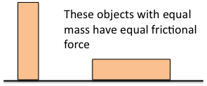

This can be rationalized by the idea of an effective area that depends on the normal force. The harder an object is pressed down the higher the effective area.

1. The frictional force does not depend on the velocity of motion, we can surmise from this that the interaction between the surfaces is not substantially modified once an object is moving.

### If I push on an object at rest will it move?

To answer this question we need to compare the applied force to the maximum force that static friction can provide, which is $\vec{F}_{fr} = \mu\vec{N}$. We should note that this force only is present when a force is applied and up to the point where the component of the applied force in the direction of motion exceeds the maximum possible static friction force the static friction force will be exactly equal and opposite to the component of the applied force in the direction of motion.

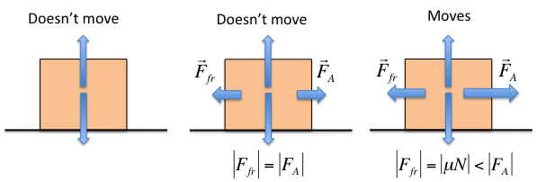

### Once we are moving

If you are either told that an object is moving or if you have evaluated that the static friction force has been overcome, then you can consider the kinetic frictional force $\vec{F}_{fr} = \mu\vec{N}$ as one of the net forces which determines an objects acceleration.

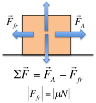

### Using Friction to stop motion

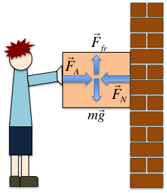

$\vec{F}_N=-\vec{F}_A$

$\vec{F}_{fr}\le \mu\vec{F}_N$

If $\vec{F}_{fr} = mg$ the box stays where it is and this requires $\vec{F}_A \ge \frac{m\vec{g}}{\mu}$

### Pushing versus Pulling (i.e. angles)

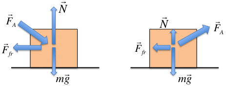

By having some component of the applied force applied vertical the normal force, and hence the frictional force can be reduced.

### The best pulling angle

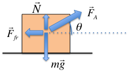

$F_{x}=F_{A}\cos\theta-\mu N=F_{A}\cos\theta-\mu (m\vec{g}-F_{A}\sin\theta)$

$\frac{dF_{x}}{d\theta}=F_{A}(-\sin\theta+\mu\cos\theta)$

Find $\theta$ for which $\frac{dF_{x}}{d\theta}=0$

$\sin\theta=\mu\cos\theta$

$\tan\theta=\mu$

### Inclines with friction

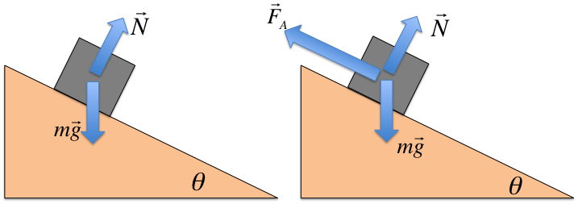

In all cases consider down the plane to be positive!

$\Sigma F_{\perp}=0$

$\vec{N}=m\vec{g}\cos\theta$

$\Sigma F_{\parallel}=mg\sin\theta-\mu mg\cos\theta-F_{A}$ or $\Sigma F_{\parallel}=mg\sin\theta+\mu mg\cos\theta-F_{A}$

depending on whether the block is moving up or down the slope. The frictional force always opposes the current velocity.

### Drag Forces

Drag forces are forces an object experiences opposing their motion in a fluid. Air is considered a fluid and so air resistance is normally considered as drag force.

Small objects moving at slow speeds can be treated as having a drag force

$\vec{F}_D = -b\vec{v}$

This equation is known as [Stoke's Law](https://en.wikipedia.org/wiki/Stokes'_law) and the parameter b depends on the nature of the fluid and the dimensions of the object. At these velocities the flow of the fluid through which the moving object passes is smooth and is called [laminar flow](https://en.wikipedia.org/wiki/Laminar_flow). Flow at higher velocities frequently becomes [turbulent](https://en.wikipedia.org/wiki/Turbulence) and so at higher velocities and for larger objects the drag is given by

$\large \vec{F}_{D}=-\frac{1}{2}\rho v^2 C_{d}A$

$\rho$ is the density of the fluid, $C_{d}$ is a parameter that depends on the shape of the object and $A$ is the area of the object.

The dependence of the drag force on area is utilized by [skydivers](http://www.youtube.com/watch?v=74zhNxgFkTQ).

### Terminal Velocity

As an object falling under the Earth's gravitational field gets faster the drag force will eventually grow to equal the gravitational force at which point it will stop accelerating and reach it's [terminal velocity](https://en.wikipedia.org/wiki/Terminal_velocity)

For the laminar drag force this is when

$ma=mg-bv=0$

$mg=bv$

$v_{terminal}=\frac{mg}{b}$

For the turbulent drag force this is when

$ma=mg-\frac{1}{2}\rho v^2 C_{d}A=0$

$mg=\frac{1}{2}\rho v^2 C_{d}A$

$v_{terminal}=\sqrt{\frac{2mg}{\rho C_{d}A}}$

### Dealing with a velocity dependent Force

To deal with velocity dependent forces we need to use integral calculus. For the laminar flow drag force

$ma=mg-bv$

$\frac{dv}{dt}=g-\frac{b}{m}v$

$\frac{dv}{g-\frac{b}{m}v}=dt$ or better $\frac{dv}{v-\frac{gm}{b}}=-\frac{b}{m}dt$

If we consider an object that starts falling from rest

$\int_{0}^{v}\frac{dv}{v-\frac{gm}{b}}=-\frac{b}{m}\int_{0}^{t}dt$

$\ln{(v-\frac{gm}{b})}-\ln{(-\frac{gm}{b})}=-\frac{b}{m}t$

$\ln{(\frac{v-\frac{gm}{b}}{-\frac{gm}{b}})}=-\frac{b}{m}t$

$v-\frac{gm}{b}=-\frac{gm}{b}e^{-\frac{b}{m}t}$

$v=\frac{gm}{b}(1-e^{-\frac{b}{m}t})$

for the higher velocity drag force you can find the derivation on Wikipedia under [derivation for the velocity v as a function of time](https://en.wikipedia.org/wiki/Terminal_velocity)

### Properties of exponential functions

The [exponential function](https://en.wikipedia.org/wiki/Exponential_function) $e^{x}$ is frequently encountered in physics. This is largely because of it's special property that is it's own derivative, ie.,

$\frac{d}{dx}e^{x}=e^{x}$

This means that frequently the solution to a [differential equation](https://en.wikipedia.org/wiki/Differential_equation) will in some way involve exponential functions.

In the equation we just derived for the velocity of a freely falling object subject to a laminar drag force we have an exponential function of the form

$e^{-kt}$

which is characteristic of [exponential decay](https://en.wikipedia.org/wiki/Exponential_decay), though in fact our function is of the form $1-e^{-kt}$ so instead of going from 1 and approaching zero it starts at zero and approaches 1.

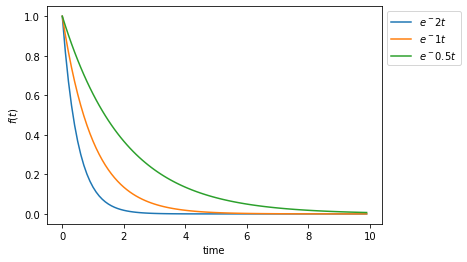

```python
# Plot an exponential function e^{at}
import numpy as np
import matplotlib.pyplot as plt
#%matplotlib inline

t=np.arange(0,10,0.1)
for a in [-2,-1,-0.5]:
    f = np.exp(a*t)
    exponent=str(a)+'t'
    plt.plot(t,f, label='$e^{}$'.format(exponent))

plt.legend(bbox_to_anchor=(1, 1), loc='upper left', ncol=1)
plt.xlabel('time')
plt.ylabel('$f(t)$')
```

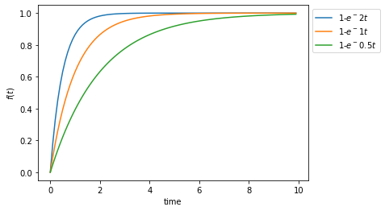

```python
# Plot an exponential function 1-e^{at}
import numpy as np
%matplotlib inline

t=np.arange(0,10,0.1)
for a in [-2,-1,-0.5]:
    f = 1- np.exp(a*t)
    exponent=str(a)+'t'
    plt.plot(t,f, label='1-$e^{}$'.format(exponent))

plt.legend(bbox_to_anchor=(1, 1), loc='upper left', ncol=1)
plt.xlabel('time')
plt.ylabel('$f(t)$')
```

### Limiting cases of our solution

We can see that our solution for the velocity as a function of time

$v=\frac{gm}{b}(1-e^{-\frac{b}{m}t})$

approaches the value we derived for the terminal velocity $v_{terminal}=\frac{gm}{b}$ as $t\to\infty$.

We can also consider the case where $m \gt\gt b$, which is where the drag force should be insignificant

$e^{-x}=1-\frac{x}{1!}+\frac{x^2}{2!}-\frac{x^3}{3!}+..$

which when $x$ is small (which $m\gt\gt b$ guarantees) can be truncated as

$e^{-x}\approx 1-x$ or for our case $e^{-\frac{b}{m}t}\approx 1-\frac{b}{m}t$

which gives

$v=gt$

### Test the equation!

Within the space available in our classroom it is hard to see a difference in velocity, but we can easily see if two objects dropped at the same time from the same height land at the same time.

The displacement as a function of time can be found by integrating the velocity.

$v=\frac{gm}{b}(1-e^{-\frac{b}{m}t})$

$y=\int_{0}^{t}v\,dt=\frac{gm}{b}[t+\frac{m}{b}e^{-\frac{b}{m}t}]_{0}^{t}$ $=\frac{gm}{b}t+\frac{gm^{2}}{b^{2}}(e^{-\frac{b}{m}t}-1)$

For spherical objects falling in air we can approximate our coefficient $b$ as $0.00034R$ where $R$ is the radius of the object. (This comes from the equation $b=6\pi\mu R$ where $\mu$ is the viscosity of the fluid the object is moving in.)

We can check Plotting the result whether we can expect to see the effects we seem to.

It looks like something's missing! What's missing for the low density objects is the bouyant force which we'll come back to much later in this course!

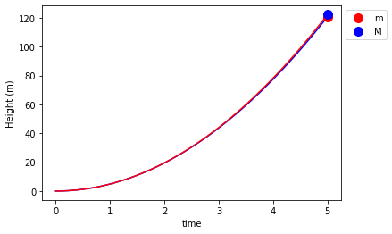

```python
# Check if two objects of same size but different masses fall at different times
import numpy as np
from matplotlib import pyplot as plt
from matplotlib import animation
plt.rcParams['animation.ffmpeg_path'] = 'ffmpeg'

R = np.zeros(2)
m = np.zeros(2)
g = 9.8 #m/s2
R[0] = 0.25 #m  T
R[1] = 0.25 #m
m[0] = 0.01 #kg
m[1] = 0.1 #kg
mu = 1.81e-5 #kg/m/s
b = R * 6 *np.pi*mu
n = 100  # Number of grid points in time
tf = 5 #s, final time
t = np.linspace(0,tf,n)
c1 = (g*m/b)
c2 = g*m**2/b**2
c3 = -b/m
y = np.zeros((2,len(t)))
y[0] = c1[0]*t + c2[0]*(np.exp(c3[0]*t)-1)
y[1] = c1[1]*t + c2[1]*(np.exp(c3[1]*t)-1)
#plt.plot(t,-y[0],t,-y[1])

# Define the meta data for the movie
FFMpegWriter = animation.writers['ffmpeg']
metadata = dict(title='Object falling in Drag', artist='Matplotlib')
writer = FFMpegWriter(fps=50, metadata=metadata)

# Initialize the movie
fig = plt.figure()

# plot the trajectory
trj0_line, = plt.plot(t, y[0], 'b')
trj1_line, = plt.plot(t, y[1], 'r')
red_circle, = plt.plot([], [], 'ro', label = 'm', markersize = 10)
blue_circle, = plt.plot([], [], 'bo', label = 'M', markersize = 10)
plt.legend(bbox_to_anchor=(1, 1), loc='upper left', ncol=1)
plt.xlabel('time')
plt.ylabel('Height (m)')

# Update the frames for the movie
with writer.saving(fig, "Data/drag.mp4", 100):
    for i in range(n):
        x0 = t[i]
        y0 = y[0,i]
        y1 = y[1,i]
        red_circle.set_data(x0, y0)
        blue_circle.set_data(x0, y1)
        writer.grab_frame()
```

```python
from IPython.display import HTML

HTML("""
<div align="middle">
<video width="80%" controls>
      <source src="Data/drag.mp4" type="video/mp4">
</video></div>""")
```

[video not shown]

### When drag does count

While drag forces did not have a significant effect in the experiment we just did, if we had a much bigger classroom we could see effects. Alternatively we could drop an object in a more viscous medium and we would see drag effects.

And of course for objects that start with higher initial velocities drag corrections can have significant effects on the trajectories of objects!

The following animation is from [wikipedia](https://en.wikipedia.org/wiki/File:Inclinedthrow.gif)

[figure not shown]